# Using RMarkdown

July 12, 2014

### Text

Text can decorated with **bold** or *italics*. It is also possible to

- create [links](http://rmarkdown.rstudio.com/)
- include mathematics like $e=mc^2$ or
  $$y = \beta_0 + \beta_1 x_1 + \beta_2 x_2$$
- embed images

Be sure to put a space after the * when you are creating bullets and a space after # when creating section headers, but **not** between $ and the mathematical formulas.

### Graphics

If the code of an R chunk produces a plot, this plot can be displayed in the resulting file.

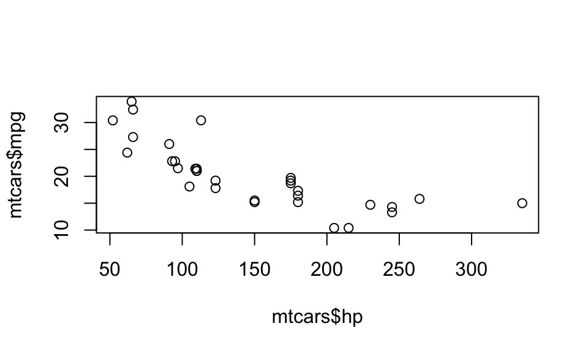

```r
plot(mtcars$mpg ~ mtcars$hp)
```

### R output

Other forms of R output are also displayed as they are produced.

```r
summary(mtcars$mpg)
```

```
##    Min. 1st Qu.  Median    Mean 3rd Qu.    Max.
##   10.40   15.42   19.20   20.09   22.80   33.90
```

You can also use “chunk options” to modify how your R chunks work. We can hide the code:

```
##    Min. 1st Qu.  Median    Mean 3rd Qu.    Max.
##   10.40   15.42   19.20   20.09   22.80   33.90
```

Or we can hide the output:

```r
summary(mtcars$mpg)
```

### Destination formats

This file can be knit to HTML, PDF, or Word. In RStudio, just select the desired output file type and click on `Knit HTML`, `Knit PDF`, or `Knit Word`. Use the dropdown menu next to that to change the desired file type.

### On your own

Please create a new markdown file called “Brief Bio” with two sections.

#### 1. Hometown

Provide your hometown and include a photo of it. Also print out some basic demographic data on your home state by using the following code.

```r
state.x77[rowNumber,]
```

You’ll need to replace `rowNumber` with the row number of your state. Also, please hide the R code and provide only the output.

#### 2. Food

Create a numbered list of your top three favorite restaurants of all time and provide links to their [Yelp](http://www.yelp.com/) page.